# Phylogenetic Analysis in R

Part 2 of Discussion Section SA4 of BIOL119-2025

Author: Your Name

Last update: 24 October, 2025

# 1 Introduction

This tutorial covers a basic phylogenetic analysis in R including the following steps. It starts with an external website query, followed by all subsequent steps in R.

1. NCBI query to retrieve sequence IDs
2. Sequence batch download
3. Cration of multiple sequence alignment
4. Building phylogentic tree with bootstrap analysis
5. Tree visualization

# 2 Creation of Input File

The following queries NCBI’s protein database to retrieve the protein IDs of all Cytochrome P450 Hydroxilases from human that are present in UniProt.

- Go to **[NCBI Protein](http://www.ncbi.nlm.nih.gov/protein)**, and run the following query: `P450 & hydroxylase & human [organism]`
- Select under “Source databases” **UniProtKB/SwissProt** as database.
- Save a *list of identifiers* (**GI List**) to your desktop via the “Send to” File drop down menu.

Note, the abbreviation “GI” often stands for “Gene ID”. However, these are *not* Entrez Gene IDs. Instead, it is more appropriate to consider these “Protein IDs.”

Because this is a deviation from SA2 (creation of identifier list *instead* of FASTA file), this screenshot helps illustrate the novel step:

[figure not shown]

Identifier Download

The result is a `sequence.gi` file.

# 3 Import Libraries

R packages required for this exercise will be loaded with the `library` command. To suppress verbose messages during the package loading process, the `suppressPackageStartupMessages` is used.

```r
suppressPackageStartupMessages({
    library(rentrez)
    library(Biostrings)
    library(org.Hs.eg.db)
    library(seqinr)#to create intermediate FASTA file
    library(msa)
    library(ape)
    library(phangorn)
    library(pheatmap)
    library(msaR)
})
```

Custom functions required for the following analyses are loaded with the `source` command from an R file named `phyloAnalysis_Fct.R`.

```r
source("phyloAnalysis_Fct.R")
```

# 4 Import Sequences

Using the protein IDs obtained from the NCBI query in the previous step, the `rentrez` package is used to import the corresponding P450 protein sequences into R.

```r
result_ID_file <- "data/phyloAnalysis/sequence.gi"
gene_IDs <- geneID_wrapper(result_ID_file)
```

Since P450s are named by subfamilies, the corresponding gene symbols are used as labels of the protein sequences. The gene symbols are obtained by querying the `org.Hs.eg.db` data package. This way it is easier to assess whether the P450 subfamilies cluster together in the downstream phylogenetic trees.

```r
gene_symbols <- mapIds( x = org.Hs.eg.db, keys = gene_IDs, column = "SYMBOL", keytype = "ENTREZID")
FASTA_file <- "rentrez-P450_UniProtKB_SwissProt-gene_symbol.fasta" # Name of output fasta file
FASTA_symbol_wrapper(result_ID_file, gene_symbols, FASTA_file)
```

# 5 Multiple Sequence Alignment

The `msa` package in Bioconductor (Bodenhofer et al. 2015) offers access to three multiple alignment software tools: ClustalW (Thompson, Higgins, and Gibson 1994), Clustal Omega (Sievers et al. 2011), and MUSCLE (Edgar 2004).

Multiple Sequence Alignments (MSA) are commonly represented using the “clustal” alignment format or the gapped FASTA format. This document utilizes Clustal Omega to generate the MSA for the downloaded P450 sequences due to its more recent implementation.

For an alternative approach, the web version of Clustal Omega can be accessed [here](https://www.ebi.ac.uk/jdispatcher/msa/clustalo).

However, using the provided R code offers several benefits beyond reproducibility. These include programmability, automation for large scale analyses, and increased flexibility.

```r
P450_SeqObj <- readAAStringSet(FASTA_file)
msa_ClustalOmega <- msa(P450_SeqObj, method = "ClustalOmega")
```

```
## using Gonnet
```

```r
msa_ClustalOmega.ape <- msaConvert(msa_ClustalOmega, type="ape::AAbin") #conversion of R object for next step
Biostrings::writeXStringSet(Biostrings::unmasked(msa_ClustalOmega), "data/phyloAnalysis/msa.fasta")
msa_bios <- readAAMultipleAlignment("data/phyloAnalysis/msa.fasta", format="fasta")
msa_bios_sub <- AAMultipleAlignment(AAStringSet(apply(as.matrix(unmasked(msa_bios))[,10:50], 1, paste0, collapse="")))
msaR::msaR(Biostrings::unmasked(msa_bios))
```

[interactive chart not shown]

# 6 Create and Visualize Distance Matrix

## 6.1 Compute Distance Matrix

To perform downstream clustering-based tree building, a distance matrix must first be computed from the multiple alignment. This is achieved using the `dist.aa` function from the `ape` package. **Note:** The distance matrix is created in this step mainly for demonstration purposes. The below tree building functions are not using it as input since they create the required distance matrix internally on the fly.

```r
msa_ClustalOmega.dist <- dist.aa(msa_ClustalOmega.ape, pairwise.deletion = FALSE, scaled = FALSE)
```

## 6.2 Inspect Distance Matrix

The distance matrix can be inspected by converting it into a `matrix` with the `as.matrix` function. The second line below outputs a small slice of the distance matrix (restricted to first 4 row and columns), and the third line demonstrates how to obtain the distance value for a specific squence pair, here “CYP8B1” and “CYP7B1”.

```r
mymatrix <- as.matrix(msa_ClustalOmega.dist)
mymatrix[1:4, 1:4]
```

```
##         CYP39A1 CYP8B1 CYP7B1 CYP7A1
## CYP39A1       0    402    418    420
## CYP8B1      402      0    351    349
## CYP7B1      418    351      0    323
## CYP7A1      420    349    323      0
```

```r
mymatrix["CYP8B1", "CYP7B1"]
```

```
## [1] 351
```

## 6.3 Visualize Distance Matrix

An efficient way to inspect distance matrices visually is to create a heatmap. The `pheatmap` function is used for this. In the resulting plot, colors represent the distance values, and the order of the rows and columns is adjusted according to distance trees.

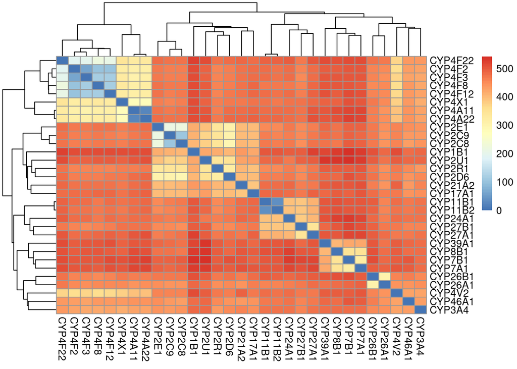

```r
pheatmap(as.matrix(msa_ClustalOmega.dist))
```

# 7 Phylogenetic Tree with Bootstrap

Phylogenetic analysis is performed by the `ape` and some other helper packages (Paradis, Claude, and Strimmer 2004). The `ape` package offers various methods for tree construction, including the Unweighted Pair Group Method with Arithmetic Averages (UPGMA) (Sokal, Michener, and others 1958) and Neighbor-Joining (NJ) (Saitou and Nei 1987). This section introduces both of these tree building methods.

## 7.1 UPGMA Tree

The follwing imports the multiple alignment of P450 protein sequences and converts it to a matrix. Using the `phangorn` package, pairwise evolutionary distances are computed under a standard amino acid substitution model such as JTT, and the ape package then applies the UPGMA (Unweighted Pair Group Method with Arithmetic Mean) algorithm to cluster sequences into a rooted cladogran (ultrametric tree if sequences evolve clockwise). To evaluate the reliability of the branches, a bootstrap analysis repeatedly resamples alignment columns, rebuilds the tree, and counts how often each grouping reappears. These percentages are added to the nodes as bootstrap support values. The number of bootstrap repetitions can be specified under the `B` argument (for real analyses use larger values, e.g. `B=1000`). Finally, the tree is plotted with bootstrap values indicating the confidence in each inferred relationship. The `upgma_bootstrap_aa` that performs this analysis only requires the multiple alignment as input. The distance matrix is recomputed by the function on the fly.

```r
msa_bios <- readAAMultipleAlignment("data/phyloAnalysis/msa.fasta", format="fasta")
m  <- as.matrix(unmasked(msa_bios))
tree_upgma <- upgma_bootstrap_aa(m, B = 100, model = "JTT")
```

```
## Running bootstraps:       100 / 100
## Calculating bootstrap values... done.
```

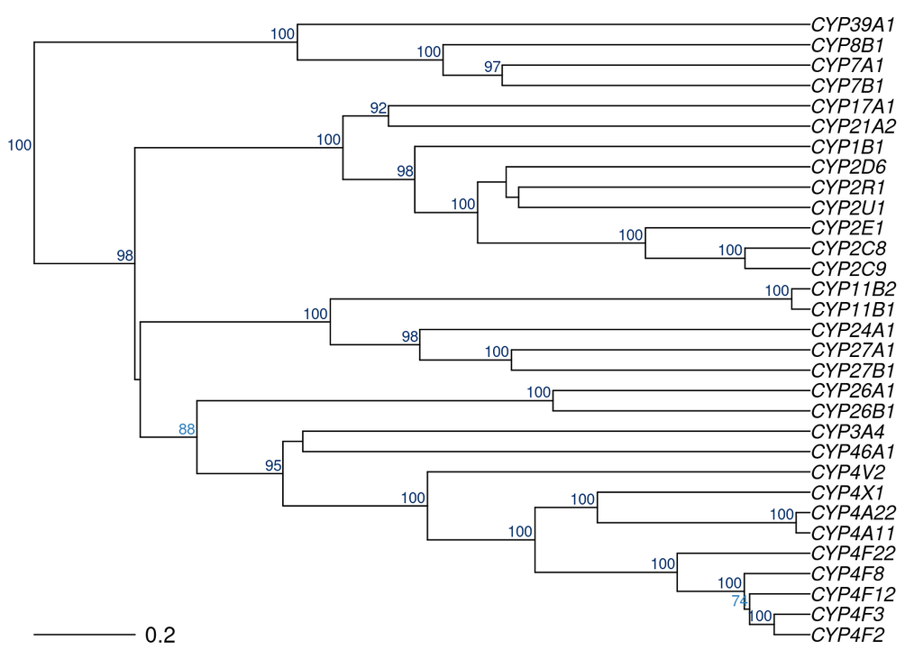

```r
plot_tree_bootstrap(tree_upgma, cutoff = 70, main = "")
```

## 7.2 Neighbor-Joining (NJ) Tree

This part of the exercise demonstrates how to build a Neighbor-Joining (NJ) phylogenetic tree from the same P450 protein alignment that was used for the UPGMA analysis. For this, the aligned amino acid sequences are imported and converted into a matrix format as before. Using the phangorn package, a distance matrix is computed under a substitution model such as JTT, which estimates how many amino acid substitutions separate each pair of sequences. The `nj` function from the `ape` package is used to constructs an unrooted Neighbor-Joining tree, which differs from UPGMA because it does not assume a constant evolutionary rate across lineages (no molecular clock). To assess the reliability of each branch, a bootstrap analysis is performed: the alignment columns are resampled many times, the NJ tree is rebuilt for each replicate, and the frequency with which each grouping reappears is recorded as a bootstrap percentage. The number of bootstrap repetitions can be specified under the `B` argument. The resulting values are included in the internal branches of the consensus NJ tree.

```r
msa_bios <- readAAMultipleAlignment("data/phyloAnalysis/msa.fasta", format="fasta")
m  <- as.matrix(unmasked(msa_bios))
tree_nj <- nj_bootstrap_aa(m, B = 100, model = "JTT")
```

```
## Running bootstraps:       100 / 100
## Calculating bootstrap values... done.
```

Because NJ produces an unrooted tree, it is then rooted either by the midpoint method (placing the root halfway between the two most distant tips) or by specifying a known outgroup sequence. In this example only the midpoint method is used. How to perform rooting with an outgroup is show but not evaluated.

```r
# Midpoint rooting
tree_nj_rooted <- phangorn::midpoint(tree_nj)
# Outgroup rooting
# tree_nj_rooted <- ape::root(tree_nj, outgroup = "YourOutgroupName", resolve.root = TRUE)
```

The final tree is plotted as a `"phylogram"` with the branch lengths proportional to evolutionary distance and bootstrap percentages shown at the internal nodes. The latter indicate how strongly each clade is supported by the data.

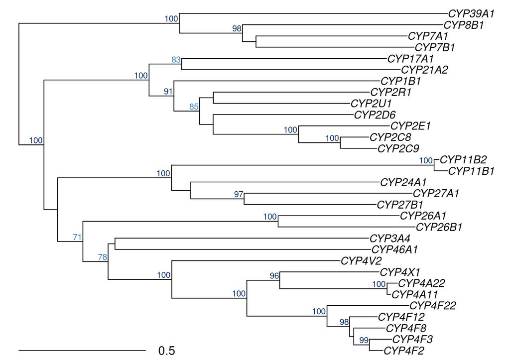

```r
plot_tree_bootstrap(tree_nj_rooted, type="phylogram", cutoff = 70, main = "")
```

Different tree shapes can be specified under the `type` argument of the `plot_tree_bootstrap` function. This is a custom function that uses internally the `plot.phylo` function of the `ape` package. To find out which tree styles are available, open its help with `?plot.phylo` and look up under the `type` argument the available options. The below creates, in addition to the above phylogram, a fan-shaped tree by specifying `"fan"` under the type argument.

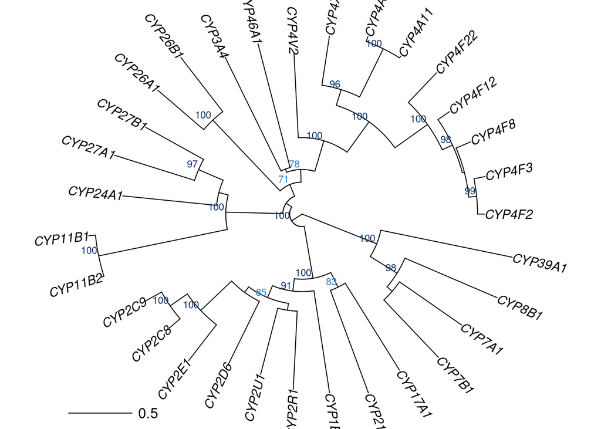

```r
plot_tree_bootstrap(tree_nj_rooted, type="fan", cutoff = 70, main = "")
```

# 8 Study Material for Homework

**Lecture LA6**

- UPGMA / NJ Implementation
- UPGMA / NJ Assumptions
- Bootstrapping Support for Tree Generation

**Procedures from this assignment (SA4)**

- Basic R Functions / Syntax
- Descriptive Statistic Calculations in R
- Knowledge of Commonly Used Functions from R Libraries

# References

Bodenhofer, Ulrich, Enrico Bonatesta, Christoph Horejš-Kainrath, and Sepp Hochreiter. 2015. “Msa: An R Package for Multiple Sequence Alignment.” *Bioinformatics* 31 (24): 3997–9.

Edgar, Robert C. 2004. “MUSCLE: Multiple Sequence Alignment with High Accuracy and High Throughput.” *Nucleic Acids Res.* 32 (5): 1792–7.

Paradis, Emmanuel, Julien Claude, and Korbinian Strimmer. 2004. “APE: Analyses of Phylogenetics and Evolution in R Language.” *Bioinformatics* 20 (2): 289–90.

Saitou, N, and M Nei. 1987. “The Neighbor-Joining Method: A New Method for Reconstructing Phylogenetic Trees.” *Mol. Biol. Evol.* 4 (4): 406–25.

Sievers, Fabian, Andreas Wilm, David Dineen, Toby J Gibson, Kevin Karplus, Weizhong Li, Rodrigo Lopez, et al. 2011. “Fast, Scalable Generation of High-Quality Protein Multiple Sequence Alignments Using Clustal Omega.” *Mol. Syst. Biol.* 7 (1): 539.

Sokal, Robert R, Charles D Michener, and others. 1958. “A Statistical Method for Evaluating Systematic Relationships.”

Thompson, J, D Higgins, and T Gibson. 1994. “CLUSTAL W: Improving the Sensitivity of Progressive Multiple Sequence Alignment Through Sequence Weighting, Position-Specific Gap Penalties and Weight Matrix Choice.” *Nucleic Acids Res.* 22 (22): 4673–80.